# Assesment Centre Data Analysis

Supriya, Sundeep and Sourav

1 July 2018

## Background information available

This data pertains to competency scores for a group of individuals in a certain organization

The scores are given by a group of assessors after observing the individual in a variety of simulated settings.

#### Importing data

We would be importing the raw data in the csv format

#### Initial check of data

We would be checking the initial construct and nature of the data

```
## 'data.frame':    143 obs. of  9 variables:
##  $ Participant.Number                           : int  1 2 3 4 5 6 7 8 9 10 ...
##  $ Cluster                                      : Factor w/ 9 levels "Acute","Chronic",..: 4 4 4 4 4 4 4 4 4 4 ...
##  $ Div                                          : Factor w/ 34 levels "AKUNA","AMPHION ",..: 1 6 1 6 1 1 6 1 6 6 ...
##  $ Zone                                         : Factor w/ 10 levels "Delhi","Gujarat",..: 7 5 1 3 5 3 1 10 7 8 ...
##  $ Analytical.Thinking                          : num  2.7 2.7 2.7 2.3 2.1 2.5 3.1 3 2.8 2.5 ...
##  $ Planning.and.Organizing                      : num  2.9 2.6 2.5 2.2 2.1 2.5 2.9 2.8 2.6 2.4 ...
##  $ Performance.Management                       : num  2.8 2.5 2.5 2.4 2.2 2.2 2.7 2.3 2.3 2.2 ...
##  $ Custodian.of.HO.systems..processes.and.values: num  2.5 2.7 2.5 2.4 1.7 2 2.5 2.8 2.8 2 ...
##  $ Coaching.and.Counselling                     : num  2.2 2.8 2.5 2.7 1.8 1.7 2.5 2 2 1.8 ...
```

The data contains 143 observations of 9 variables

The variables are

- Participant Number (is the identifier for the individual)
- Cluster : This has 9 unique kinds of observations
- Div : There are 34 unique kinds of observations
- Zone : There are 10 unique kinds of observations
- Analytical thinking score
- Planning and organizing score
- Performance management score
- Custodian of HO systems, processes and values score
- Coaching and counselling score

The only variable which we feel is not in the proper ’class" is the participant number variable which has been categorized as number.

I would be doing a coercion to string since this pertains to an identifier

```
##  chr [1:143] "1" "2" "3" "4" "5" "6" "7" "8" "9" "10" "11" "12" "13" ...
```

#### Cleaning Data

For doing the analysis we would be compressing and simplifying the varaiable names

- Participant Number : Emp
- Cluster : Cluster
- Div : Div
- Zone : Zone
- Anlytical thinking score : ATS
- Planning and Organizing score : POS
- Performance management score : PMS
- Custodian of HO systems, processes and values score : HOS
- Coaching and counselling score : CCS

|  | Emp | Cluster | Div | Zone | ATS | POS | PMS | HOS | CCS |
| --- | --- | --- | --- | --- | --- | --- | --- | --- | --- |
| 1 | 1 | CVD | AKUNA | TamilNadu | 2.7 | 2.9 | 2.8 | 2.5 | 2.2 |
| 2 | 2 | CVD | AVIOR | Maharashtra | 2.7 | 2.6 | 2.5 | 2.7 | 2.8 |
| 3 | 3 | CVD | AKUNA | Delhi | 2.7 | 2.5 | 2.5 | 2.5 | 2.5 |
| 4 | 4 | CVD | AVIOR | Karnataka | 2.3 | 2.2 | 2.4 | 2.4 | 2.7 |
| 5 | 5 | CVD | AKUNA | Maharashtra | 2.1 | 2.1 | 2.2 | 1.7 | 1.8 |
| 6 | 6 | CVD | AKUNA | Karnataka | 2.5 | 2.5 | 2.2 | 2.0 | 1.7 |

## Exploratory Analysis

We will check what the data looks like

### Initial Data check

```
##      Emp                    Cluster         Div               Zone
##  Length:143         CVD         :37   SOLARES :  7   Delhi      :29
##  Class :character   Gastro      :24   SUN     :  7   Maharashtra:27
##  Mode  :character   Acute       :20   ARIAN   :  6   West Bengal:26
##                     CNS         :20   AVIOR   :  6   TamilNadu  :24
##                     Semi-Chronic:13   SYGNUS  :  6   Telangana  :12
##                     Derma       :12   AKUNA   :  5   Karnataka  :10
##                     (Other)     :17   (Other) :106   (Other)    :15
##       ATS             POS             PMS             HOS
##  Min.   :2.000   Min.   :1.800   Min.   :1.500   Min.   :1.500
##  1st Qu.:2.300   1st Qu.:2.200   1st Qu.:2.000   1st Qu.:2.000
##  Median :2.400   Median :2.400   Median :2.200   Median :2.200
##  Mean   :2.535   Mean   :2.424   Mean   :2.265   Mean   :2.124
##  3rd Qu.:2.700   3rd Qu.:2.600   3rd Qu.:2.500   3rd Qu.:2.300
##  Max.   :3.300   Max.   :3.100   Max.   :3.200   Max.   :3.000
##
##       CCS
##  Min.   :1.500
##  1st Qu.:1.800
##  Median :2.000
##  Mean   :2.073
##  3rd Qu.:2.300
##  Max.   :2.900
##
```

#### Checking for the zones specifically

```
##         Delhi       Gujarat     Karnataka        Kerala   Maharashtra
##            29             3            10             1            27
##     Rajasthan     TamilNadu     Telangana Uttar Pradesh   West Bengal
##             2            24            12             9            26
```

#### Initial findings

There does not seem to be enough data to start running analysis to see differences between all the Zones

There is not enough data for Gujarat, Rajasthan, or Kerala.

### Checking distribution of the data

we would now be checking how the score data is distributed for each of the competencies

#### Histogram of scores

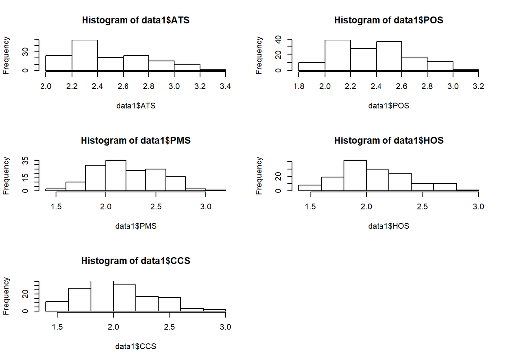

None of the Histograms looks visually similar. Hence we conclude that these are mostly different distributions

We would be checking if there is any visual difference that exists between the various competency scores

To do this, I would be creating a different data set with the identifiers of emp, Zone, cluster and zone

|  | Emp | Cluster | Div | Zone | variable | value |
| --- | --- | --- | --- | --- | --- | --- |
| 1 | 1 | CVD | AKUNA | TamilNadu | ATS | 2.7 |
| 2 | 2 | CVD | AVIOR | Maharashtra | ATS | 2.7 |
| 3 | 3 | CVD | AKUNA | Delhi | ATS | 2.7 |
| 4 | 4 | CVD | AVIOR | Karnataka | ATS | 2.3 |
| 5 | 5 | CVD | AKUNA | Maharashtra | ATS | 2.1 |
| 6 | 6 | CVD | AKUNA | Karnataka | ATS | 2.5 |

#### Check to see if there is any difference between difference competency score

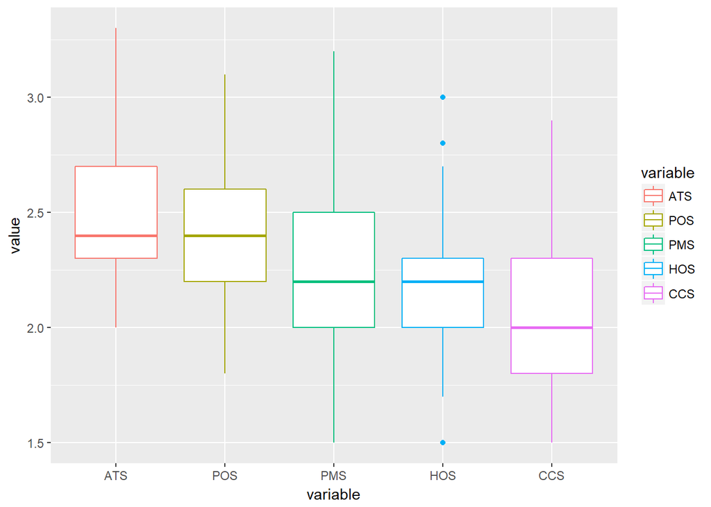

From this, we see that there seems to exist visual differences between the various competencies

We would be checking to see if there is any statistically significant difference between the competency scores ( The one we have seen visually)

the 1st test we would conduct is going to be a Anova test.

```
##
##  One-way analysis of means (not assuming equal variances)
##
## data:  value and variable
## F = 58.102, num df = 4.0, denom df = 354.8, p-value < 2.2e-16
```

We see that the p value is near zero. Hence we reject the Null hypothesis and infer that there is a statistically significant difference in scores within the average scores of different competencies